```python
#Google-oriented program.
import os
import pandas as pd
import scipy
import numpy as np
import statsmodels.api as sm
import pylab
import matplotlib.pyplot as plt
import datetime
from pandas.tseries.offsets import MonthEnd
import numpy as np
import matplotlib.pyplot as plt
from scipy.stats import linregress
import re
```

# question-I

```python
port = pd.read_excel('size_port.xlsx')
port = port.rename(columns={'Unnamed: 0':0})
port[0]=pd.to_datetime(port[0].apply(lambda x:str(x))
                       ,format = '%Y%m')+MonthEnd(0)
port[0] = port[0].apply(lambda x:x.strftime('%Y%m%d')).astype(int)
port = port[(port[0] >= 19630731)&(port[0] <= 20200630)]

factor = pd.read_csv('ff3.csv')
factor= factor.rename(columns={'Unnamed: 0':0})
factor[0]=pd.to_datetime(factor[0].apply(lambda x:str(x))
                         ,format = '%Y%m')+MonthEnd(0)
factor[0] = factor[0].apply(lambda x:x.strftime('%Y%m%d')).astype(int)
factor =factor[(factor[0] >= 19630731)&(factor[0] <= 20200630)]
factor = factor.set_index(0,drop = True)
port = port.set_index(0,drop = True)
```

```python
eRE = port
for i in eRE.columns:
    eRE[i] = eRE[i]-factor['RF']
```

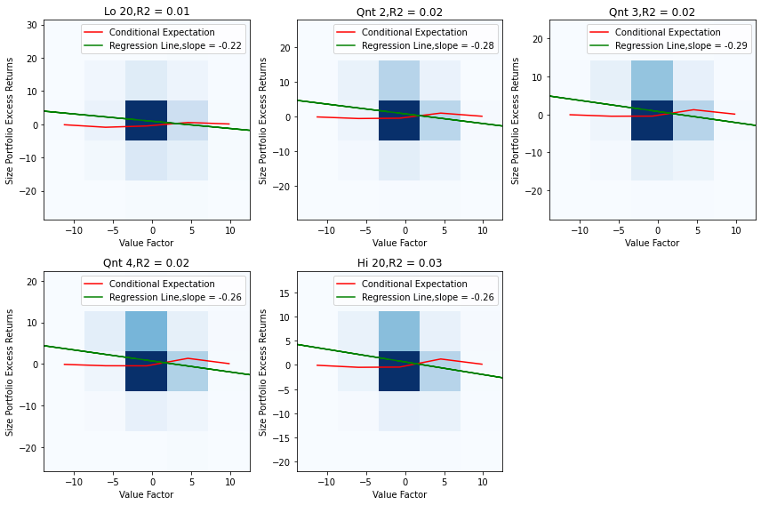

```python
fig, axes = plt.subplots(2, 3, figsize=(12, 8))
size_labels = port.columns

for x in range(5):
    ax = axes[x // 3, x % 3]
    size_portfolios_excess = eRE.values[:,x]
    value_factor_excess = factor['HML'].values
    hist, xedges, yedges = np.histogram2d(value_factor_excess,
                                          size_portfolios_excess,bins=5)
    x_center = []
    for i in range(0,len(xedges)-1):
        x_center.append(xedges[i]/2+xedges[i+1]/2)
    x_center = np.array(x_center)
    conditional_expectation = pd.DataFrame(hist/hist.sum()).sum().values
    conditional_expectation = conditional_expectation* x_center
    ax.plot(x_center, conditional_expectation, color='red',
            label='Conditional Expectation')

    ax.hist2d( value_factor_excess,
              size_portfolios_excess,
              bins=[xedges, yedges],
              cmap='Blues')


    # Perform linear regression
    slope, intercept, r_value, p_value, std_err = linregress(value_factor_excess,
                                                             size_portfolios_excess)
    regression_line = intercept + slope * value_factor_excess
    slope = np.round(slope,2)
    ax.plot(value_factor_excess, regression_line,
            color='green',
            label='Regression Line,slope = '+str(slope))
    r_value = np.round(r_value**2,2)
    ax.set_xlabel('Value Factor')
    ax.set_ylabel('Size Portfolio Excess Returns')

    ax.set_title(size_labels[x]+',R2 = '+str(r_value))
    ax.legend()

# Add a blank subplot if needed
axes[1, 2].axis('off')

plt.tight_layout()
plt.show()
```

Question1:Describe the differences between the conditional expectation and the regression line. Do the differences change across size portfolios

"The notable distinction lies in the behavior of conditional expectations, which exhibit an initial decrease followed by an increase. Ultimately, they culminate in a decrease once more. Additionally, the regression line consistently maintains a negative slope, indicating a negative correlation between the value factor and excess returns. This pattern persists consistently across all portfolios."

Question 2 What does the general pattern in the slope of the regression line tell you about the co-movement in size portfolios and the value factor? What does the R-squared of each regression tell you?

"The negative slope observed in all portfolios signifies that when a portfolio has a higher exposure to the value factor, there is a greater likelihood of a decline in excess returns. And the slope of every portfolio is close to each other. Furthermore, the increasing R2 values as the portfolio size grows indicate that this effect becomes more pronounced with larger holdings, although these values remain relatively low, suggesting that this effect is relatively minor in magnitude."

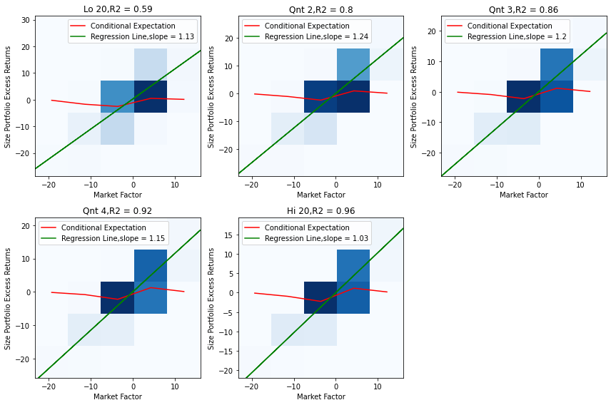

```python
fig, axes = plt.subplots(2, 3, figsize=(12, 8))
size_labels =port.columns

for x in range(5):
    ax = axes[x // 3, x % 3]
    size_portfolios_excess = eRE.values[:,x]
    value_factor_excess = factor['Mkt-RF'].values
    hist, xedges, yedges = np.histogram2d(value_factor_excess,
                                          size_portfolios_excess,
                                          bins=5)
    x_center = []
    for i in range(0,len(xedges)-1):
        x_center.append(xedges[i]/2+xedges[i+1]/2)
    x_center = np.array(x_center)
    conditional_expectation = pd.DataFrame(hist/hist.sum()).sum().values
    conditional_expectation = conditional_expectation* x_center
    ax.plot(x_center, conditional_expectation,
            color='red', label='Conditional Expectation')

    ax.hist2d( value_factor_excess,
              size_portfolios_excess,
              bins=[xedges, yedges],
              cmap='Blues')


    # Perform linear regression
    slope, intercept, r_value, p_value, std_err = linregress(value_factor_excess,
                                                             size_portfolios_excess)
    regression_line = intercept + slope * value_factor_excess
    slope = np.round(slope,2)
    ax.plot(value_factor_excess,
            regression_line,
            color='green',
            label='Regression Line,slope = '+str(slope))
    r_value = np.round(r_value**2,2)
    ax.set_xlabel('Market Factor')
    ax.set_ylabel('Size Portfolio Excess Returns')

    ax.set_title(size_labels[x]+',R2 = '+str(r_value))
    ax.legend()

# Add a blank subplot if needed
axes[1, 2].axis('off')

plt.tight_layout()
plt.show()
```

Question1:Describe the differences between the conditional expectation and the regression line. Do the differences change across size portfolios

The condition expectation remain stable and then suddenly increase and the decrease. Not like the regression line, which keep increase all the time. Showing that in fact the best of a portfolio is neither too close nor too away for market.

Question 2 What does the general pattern in the slope of the regression line tell you about the co-movement in size portfolios and the value factor? What does the R-squared of each regression tell you?

"The positive slope observed in all portfolios signifies that when a portfolio has a higher exposure to the market factor, there is a greater likelihood of a increase in excess returns. And the slope of every portfolio is close to each other.

Furthermore, the increasing R2 values as the portfolio size grows indicate that this effect becomes more pronounced with larger holdings, and portfolios formed with larger stocks would have more exposure to market factor.

## Question - II

```python
port = pd.read_excel('indus_port.xlsx')
port = port.rename(columns = {'Unnamed: 0':0})
port[0]=pd.to_datetime(port[0].apply(lambda x:str(x)),
                       format = '%Y%m')+MonthEnd(0)
port[0] = port[0].apply(lambda x:x.strftime('%Y%m%d')).astype(int)
port = port[(port[0] >= 19630731)&(port[0] <= 20200630)]
port = port.sort_values(0,ascending=True)
factor = pd.read_csv('ff3.csv')

factor= factor.rename(columns={'Unnamed: 0':0})
factor[0]=pd.to_datetime(factor[0].apply(lambda x:str(x)),
                         format = '%Y%m')+MonthEnd(0)
factor[0] = factor[0].apply(lambda x:x.strftime('%Y%m%d')).astype(int)
factor =factor[(factor[0] >= 19630731)&(factor[0] <= 20200630)]
factor = factor.sort_values(0,ascending=True)
```

Question 1 Describe the industry portfolios. How is an industry defined? Generally speaking, How do the 10 and 17 industry portfolios differ in definition from the 5 industry portfolios?

We assign each NYSE, AMEX, and NASDAQ stock to an industry portfolio at the end of June of year t based on its four-digit SIC code at that time. (We use Compustat SIC codes for the fiscal year ending in calendar year t-1. Whenever Compustat SIC codes are not available, we use CRSP SIC codes for June of year t.) We then compute returns from July of t to June of t+1.

These portfolios are further divided into five main industry groups:

1. **Consumer (Cnsmr):** This category encompasses Consumer Durables, Nondurables, Wholesale, Retail, and certain Services (such as Laundries and Repair Shops).
2. **Manufacturing (Manuf):** This group includes stocks related to Manufacturing, Energy, and Utilities.
3. **High Technology (HiTech):** Stocks within this category consist of companies involved in Business Equipment, Telephone, and Television Transmission.
4. **Healthcare (Hlth):** The Healthcare industry portfolio includes stocks from Healthcare, Medical Equipment, and Drugs sectors.
5. **Other:** This category encompasses various industries like Mines, Construction, Building Materials, Transportation, Hotels, Business Services, Entertainment, and Finance.

Moreover, a more detailed breakdown is applied to 17 and 10 industry portfolios, which are as follows:

For 17 Industries:

1. Food
2. Mines
3. Oil
4. Clothing
5. Durables
6. Chemicals
7. Consumer Goods
8. Construction
9. Steel
10. Fabricated Products
11. Machinery
12. Cars
13. Transportation
14. Utilities
15. Retail
16. Financial
17. Others

For 10 Industries:

1. Non-Durables (NoDur)
2. Durables (Durbl)
3. Manufacturing (Manuf)
4. Energy (Enrgy)
5. High Technology (HiTec)
6. Telecommunications (Telcm)
7. Retail Shops (Shops)
8. Healthcare (Hlth)
9. Utilities (Utils)
10. Others

It's important to note that the level of granularity varies, with the 17 and 10 industry portfolios providing more detailed classifications compared to the broader 5 industry categories.

```python
port = port.set_index(0,drop = True)
excess_re = port/100
for i in excess_re.columns:
    excess_re[i] = excess_re[i].values -factor['RF'].values/100
mkt_rf = factor['Mkt-RF']/100
null = 0.006
T = len(excess_re)
tstat_list = []
for i in excess_re:
    xret = excess_re[i]
    se = xret.std()/np.sqrt(T)
    tstat = (xret.mean()-null)/se
    tstat_list.append(tstat)

t_output = pd.DataFrame(tstat_list,index = excess_re.columns).T
t_output
```

|  | Cnsmr | Manuf | HiTec | Hlth | Other |
| --- | --- | --- | --- | --- | --- |
| 0 | 0.144148 | -0.508838 | -0.080955 | 0.527722 | -0.305288 |

```python
from scipy import stats
a = 0.01
tcrit= stats.t.ppf(1-a/2, T-1)
tcrit
```

```
2.5830467397126347
```

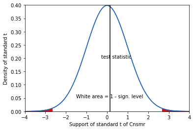

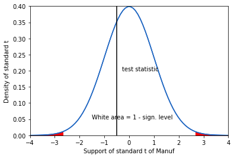

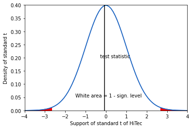

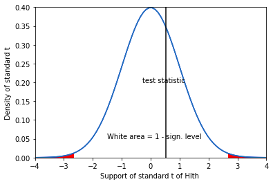

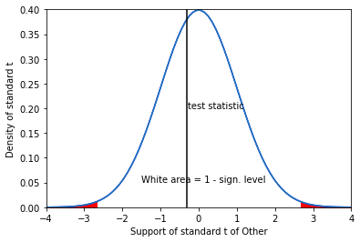

```python
for i in t_output.columns:
    x = np.linspace(-5, 5, 100)
    y = stats.t.pdf(x, T-1)
    tdraw = pd.DataFrame(y,index = x).reset_index()
    plt.plot(tdraw['index'],
    tdraw[0],
    color = 'blue')
    plt.fill_between(tdraw[tdraw['index']>tcrit]['index'],
    tdraw[tdraw['index']>tcrit][0],
    color = 'red'
    )
    plt.plot(tdraw['index'], tdraw[0])
    plt.fill_between(tdraw[tdraw['index']<-tcrit]['index'],
    tdraw[tdraw['index']<-tcrit][0],
    color = 'red'
    )
    plt.ylim(ymin=0)
    plt.ylim(ymax=0.4)
    plt.xlim(xmin = -4)
    plt.xlim(xmax = 4)
    plt.axvline(t_output[i].iloc[0],color = 'black')
    plt.text(tstat+0.01, 0.2, 'test statistic')
    plt.text(-1.5, 0.05, 'White area = 1 - sign. level')
    plt.xlabel('Support of standard t of '+i)
    plt.ylabel('Density of standard t')
    plt.show()
```

There is no difference. Since the portfolios is huge which includes hugh volumes of stocks,they are co close to market return.

```python
var_list = []
for i in port.columns:
    y = port[i]/100
    X = factor[['Mkt-RF', 'SMB', 'HML']]/100
    X[1] = 1
    X = X[[1,'Mkt-RF', 'SMB', 'HML']]
    cov_X = np.cov(X, rowvar=False)
    var_y = np.var(y)
    bhat = np.matmul(np.matmul(np.linalg.matrix_power(
        np.matmul(X.T.values,
                         X.values),-1),
                               X.T.values),y)
    var_decomp = np.outer(bhat, bhat) * cov_X / var_y
    var_list.append(np.diag(var_decomp))
var_list = pd.DataFrame(var_list,
                        index = port.columns,
                        columns =[1,'Mkt-RF', 'SMB', 'HML'] )
var_list
```

|  | 1 | Mkt-RF | SMB | HML |
| --- | --- | --- | --- | --- |
| Cnsmr | 0.0 | 0.849994 | 0.000016 | 0.005149 |
| Manuf | 0.0 | 0.916734 | 0.003469 | 0.021131 |
| HiTec | 0.0 | 0.712387 | 0.001327 | 0.034679 |
| Hlth | 0.0 | 0.589366 | 0.018661 | 0.032279 |
| Other | 0.0 | 0.930389 | 0.000605 | 0.046253 |

What we observe is that the primary source of return variance in all five portfolios is their exposure to the market. When the market experiences a decline, it's likely that these companies also see a decrease in their returns. Variance attributed to exposure to size or value factors is notably low. In essence, this indicates that these portfolios generate alpha by being rewarded for their exposure to size and value factors without their returns being strongly influenced by these risk factors.

This is the first key finding. Moreover, it underscores the significant disparities in Mkt-RF (Market Risk-Free) across different industries. As we address the second question, it becomes evident that industry plays a pivotal role when attempting to elucidate average returns. This is because various industries exhibit diverse levels of market exposure, contributing to the variation in their performance.

# Qeustion 3

```python
mpegx= pd.read_excel('MPEGX.xlsx')
mpegx = mpegx.rename(columns = {"As of Date":'date',
                               'MPEGX ($)':'nav'} )
mpegx['date'] = pd.to_datetime(mpegx['date'],format='%m/%d/%Y')
mpegx= mpegx.sort_values('date',ascending=  True)
mpegx['return'] = mpegx['nav'].pct_change()*100
mpegx= mpegx[['date','return']].rename(
    columns = {'return':'mpegx_return'}
)
mpaix = pd.read_excel('MPAIX.xlsx')[['As of Date','MPAIX ($)']]
mpaix = mpaix.rename(columns = {'As of Date':'date',
                                 'MPAIX ($)':'nav'})
mpaix['date'] = pd.to_datetime(mpaix['date'],format='%m/%d/%Y')
mpaix = mpaix.sort_values('date',ascending=  True)
mpaix['return'] = mpaix['nav'].pct_change()*100
mpaix = mpaix[['date','return']].rename(
    columns = {'return':'mpaix_return'}
)
seegx = pd.read_excel('SEEGX.xlsx')
seegx['Date'] = pd.to_datetime(seegx['Date'])
seegx['Return'] = seegx['Return'].apply(lambda x:re.sub('%','',x))
seegx['Return'] = seegx['Return'].astype(float)
seegx  = seegx[['Date','Return']].rename(columns = {'Date':'date',
                                           "Return":'seegx_return'})

olgax = pd.read_excel('OLGAX.xlsx')
olgax['Date'] = pd.to_datetime(olgax['Date'])

olgax['Return'] = olgax['Return'].apply(lambda x:re.sub('%','',x))
olgax['Return'] = olgax['Return'].astype(float)

olgax  = olgax[['Date','Return']].rename(columns = {'Date':'date',
                                           "Return":'olgax_return'})
ivv = pd.read_excel('IVV.xlsx')
ivv.columns = ['date','ivv_return']
ivv['date'] = pd.to_datetime(ivv['date'])
ijh = pd.read_excel('IJH.xlsx')
ijh.columns = ['date','ijh_return']
ijh['date'] = pd.to_datetime(ijh['date'])
data = mpegx.copy()
for i in [mpaix,seegx,olgax,ivv,ijh]:
    data = pd.merge(data,i,on = 'date',how = 'inner')
data = data.dropna()
factor = pd.read_csv('ff3.csv')
factor= factor.rename(columns={'Unnamed: 0':0})
factor[0]=pd.to_datetime(factor[0].apply(lambda x:str(x)),
                         format = '%Y%m')+MonthEnd(0)
data = pd.merge(data,factor.rename(columns = {0:'date'}),
                on = 'date',how = 'inner')
```

**I have selected six funds, with two each from JPMorgan, Morgan Stanley, and BlackRock:**

These funds encompass a diverse range of investment objectives and strategies, allowing for a well-rounded investment portfolio that covers various asset classes and market segments.

The data period is from July 2008 to July 2023

First is plot

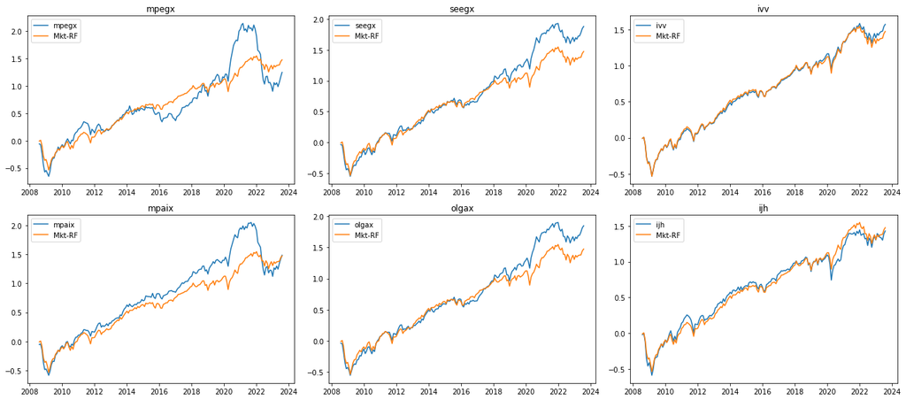

```python
fig, axs = plt.subplots(2, 3, figsize=(18, 8))

axs[0, 0].plot(data['date'],
               (data['mpegx_return']/100+1).transform(np.log).cumsum(),
               label = 'mpegx')
axs[0, 0].plot(data['date'],
               (data['Mkt-RF']/100+1).transform(np.log).cumsum(),
               label = 'Mkt-RF')
axs[0, 0].set_title('mpegx')
axs[0,0].legend()

axs[1, 0].plot(data['date'],
               (data['mpaix_return']/100+1).transform(np.log).cumsum(),
               label = 'mpaix')
axs[1, 0].plot(data['date'],
               (data['Mkt-RF']/100+1).transform(np.log).cumsum(),
               label = 'Mkt-RF')
axs[1, 0].set_title('mpaix')
axs[1,0].legend()

axs[0, 1].plot(data['date'],
               (data['seegx_return']/100+1).transform(np.log).cumsum(),
               label = 'seegx')
axs[0, 1].plot(data['date'],
               (data['Mkt-RF']/100+1).transform(np.log).cumsum(),
               label = 'Mkt-RF')
axs[0, 1].set_title('seegx')
axs[0,1].legend()

axs[1, 1].plot(data['date'],
               (data['olgax_return']/100+1).transform(np.log).cumsum(),
               label = 'olgax')
axs[1, 1].plot(data['date'],
               (data['Mkt-RF']/100+1).transform(np.log).cumsum(),
               label = 'Mkt-RF')
axs[1, 1].set_title('olgax')
axs[1,1].legend()

axs[0, 2].plot(data['date'],
               (data['ivv_return']/100+1).transform(np.log).cumsum(),
               label = 'ivv')
axs[0, 2].plot(data['date'],
               (data['Mkt-RF']/100+1).transform(np.log).cumsum(),
               label = 'Mkt-RF')
axs[0, 2].set_title('ivv')
axs[0,2].legend()

axs[1, 2].plot(data['date'],
               (data['ijh_return']/100+1).apply(lambda x:np.log(x)).cumsum(),
               label = 'ijh')
axs[1, 2].plot(data['date'],
               (data['Mkt-RF']/100+1).transform(np.log).cumsum(),
               label = 'Mkt-RF')
axs[1, 2].set_title('ijh')
axs[1,2].legend()


plt.tight_layout()

plt.show()
```

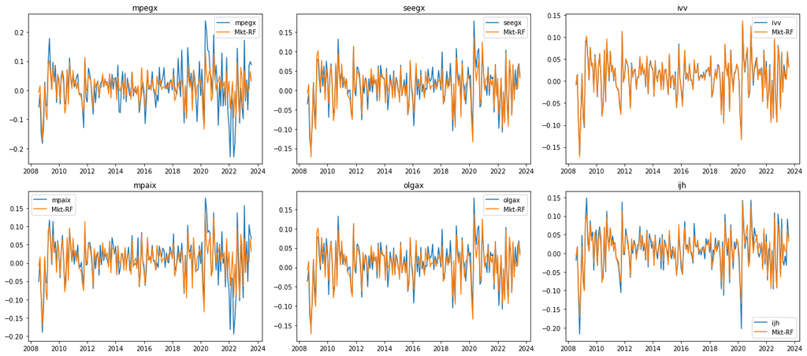

```python
fig, axs = plt.subplots(2, 3, figsize=(18, 8))

axs[0, 0].plot(data['date'], data['mpegx_return']/100,label = 'mpegx')
axs[0, 0].plot(data['date'], data['Mkt-RF']/100,label = 'Mkt-RF')
axs[0, 0].set_title('mpegx')
axs[0,0].legend()

axs[1, 0].plot(data['date'], (data['mpaix_return']/100),label = 'mpaix')
axs[1, 0].plot(data['date'], (data['Mkt-RF']/100),label = 'Mkt-RF')
axs[1, 0].set_title('mpaix')
axs[1,0].legend()

axs[0, 1].plot(data['date'], (data['seegx_return']/100),label = 'seegx')
axs[0, 1].plot(data['date'], (data['Mkt-RF']/100),label = 'Mkt-RF')
axs[0, 1].set_title('seegx')
axs[0,1].legend()

axs[1, 1].plot(data['date'], (data['olgax_return']/100),label = 'olgax')
axs[1, 1].plot(data['date'], (data['Mkt-RF']/100),label = 'Mkt-RF')
axs[1, 1].set_title('olgax')
axs[1,1].legend()

axs[0, 2].plot(data['date'], (data['ivv_return']/100),label = 'ivv')
axs[0, 2].plot(data['date'], (data['Mkt-RF']/100),label = 'Mkt-RF')
axs[0, 2].set_title('ivv')
axs[0,2].legend()

axs[1, 2].plot(data['date'], (data['ijh_return']/100),label = 'ijh')
axs[1, 2].plot(data['date'], (data['Mkt-RF']/100),label = 'Mkt-RF')
axs[1, 2].set_title('ijh')
axs[1,2].legend()


plt.tight_layout()

plt.show()
```

Analysis 1: If they have a mean return higher than 0?

```python
excess_re = data[[ 'mpegx_return', 'mpaix_return',
                  'seegx_return', 'olgax_return',
       'ivv_return', 'ijh_return']]/100
for i in excess_re.columns:
    excess_re[i] = excess_re[i].values -data['RF'].values/100
null = 0
T = len(excess_re)
tstat_list = []
for i in excess_re:
    xret = excess_re[i]
    se = xret.std()/np.sqrt(T)
    tstat = (xret.mean()-null)/se
    tstat_list.append(tstat)
from scipy import stats
a = 0.01
tcrit= stats.t.ppf(1-a/2, T-1)
t_output = pd.DataFrame(tstat_list,index = excess_re.columns)
t_output['t'] = stats.t.ppf(1-a/2, T-1)
t_output['judge'] = t_output[0] > t_output['t']
t_output = t_output.rename(columns = {0:'t_value'})
t_output
```

|  | t_value | t | judge |
| --- | --- | --- | --- |
| mpegx_return | 1.649415 | 2.603418 | False |
| mpaix_return | 2.159036 | 2.603418 | False |
| seegx_return | 2.921513 | 2.603418 | True |
| olgax_return | 2.873654 | 2.603418 | True |
| ivv_return | 2.677748 | 2.603418 | True |
| ijh_return | 2.158005 | 2.603418 | False |

Analysis - 2 how about their aplh and beta?

```python
bhat_list = []
for i in excess_re.columns:
    y = excess_re[i]
    X = pd.DataFrame(data['Mkt-RF']/100).reset_index()
    X['index'] = 1
    X = X.values
    _,K = X.shape
    bhat = np.matmul(np.matmul(np.linalg.matrix_power(np.matmul(X.T,X),-1),X.T),y)
    bhat_list.append(bhat)
bhat_list = pd.DataFrame(bhat_list,
                         index = excess_re.columns).rename(columns = {0:'a',
                                                                      1:'b'})
# Les's combine with t
total_result = pd.merge(bhat_list
                        ,t_output,
                        left_index = True,
                        right_index = True,how = 'left')
total_result
```

|  | a | b | t_value | t | judge |
| --- | --- | --- | --- | --- | --- |
| mpegx_return | -0.001835 | 1.173130 | 1.649415 | 2.603418 | False |
| mpaix_return | -0.000194 | 1.029004 | 2.159036 | 2.603418 | False |
| seegx_return | 0.001925 | 0.993104 | 2.921513 | 2.603418 | True |
| olgax_return | 0.001742 | 0.993526 | 2.873654 | 2.603418 | True |
| ivv_return | 0.000243 | 0.964261 | 2.677748 | 2.603418 | True |
| ijh_return | -0.001424 | 1.107374 | 2.158005 | 2.603418 | False |

Three factor analyss

```python
para_list =  pd.DataFrame()
output = []
for i in excess_re.columns:
    y = excess_re[i]
    X = data[['Mkt-RF', 'SMB', 'HML']]/100
    X[1] = 1
    X = X[[1,'Mkt-RF', 'SMB', 'HML']]
    _,K = X.shape
    bhat = np.matmul(np.matmul(np.linalg.matrix_power(
        np.matmul(X.T.values,
                X.values),-1),
                               X.T.values),y)
    yhat = np.matmul(X.values,bhat)
    uhat = y - yhat
    XtX_inv = np.linalg.inv(X.T @ X)
    uhat_squared = np.diag(uhat**2)
    varbhat = XtX_inv @ (np.matrix(X.T @ uhat_squared )@ np.matrix(X)) @ XtX_inv
    se = np.sqrt(np.diag(varbhat).astype(float))
    tstats = bhat/se
    show_output = pd.DataFrame(bhat,columns = ['bhat'])
    show_output['se'] = se
    show_output['tstats'] = tstats
    show_output.index = ['a','b','smb','hml']
    output.append(show_output)
    para_list = para_list.append(
        pd.DataFrame(show_output['bhat']
                    ).rename(
            columns = {'bhat':i}).T
    )
para_list = para_list.reset_index().rename(
    columns ={ "index":'name'}
)
para_list['name'] = para_list['name'].apply(lambda x:x.split('_')[0])
para_list
```

|  | name | a | b | smb | hml |
| --- | --- | --- | --- | --- | --- |
| 0 | mpegx | -0.003193 | 1.135783 | 0.801644 | -0.820013 |
| 1 | mpaix | -0.001455 | 1.069121 | 0.185127 | -0.569444 |
| 2 | seegx | 0.000945 | 1.045379 | -0.013992 | -0.38823 |
| 3 | olgax | 0.000764 | 1.045686 | -0.013715 | -0.387709 |
| 4 | ivv | 0.000146 | 0.989442 | -0.151248 | 0.013306 |
| 5 | ijh | -0.000614 | 1.012109 | 0.400684 | 0.187411 |

You could see that all of them have positive exposure on market And some of them have negative exporuse on smb and hml

Analysis 3: Would the invest styles change over time.

In the financial industry, particularly in the realm of Fund of Funds (FOF), the Fama-French Three-Factor Model is a crucial analytical tool for assessing a fund's investment style. When the exposure to the Size (SMB) factor is substantial, it indicates that the portfolio demonstrates a preference for specific companies. I've had experience performing such analyses in my prior professional roles, and as such, I'm interested in monitoring how investment styles evolve over time within portfolios.

To achieve this, I conduct Fama-French Three-Factor Regressions in rolling windows of three years. Each data point on the subsequent graph represents the exposure of the excess return to various factors over a three-year period. This approach allows us to compare how the fund's exposure corresponds to its returns, helping us identify which investment styles tend to yield the best performance.

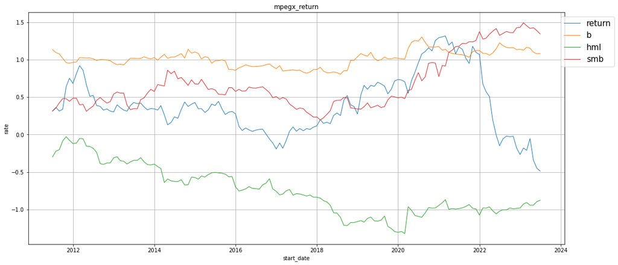

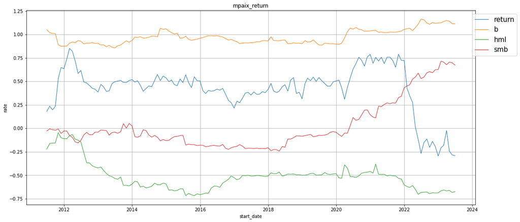

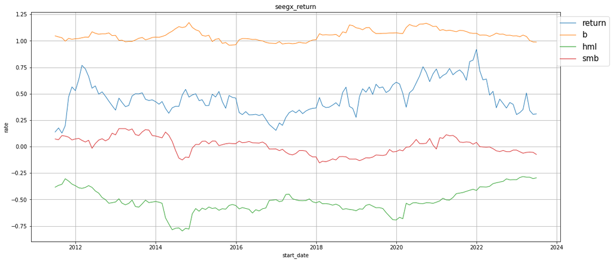

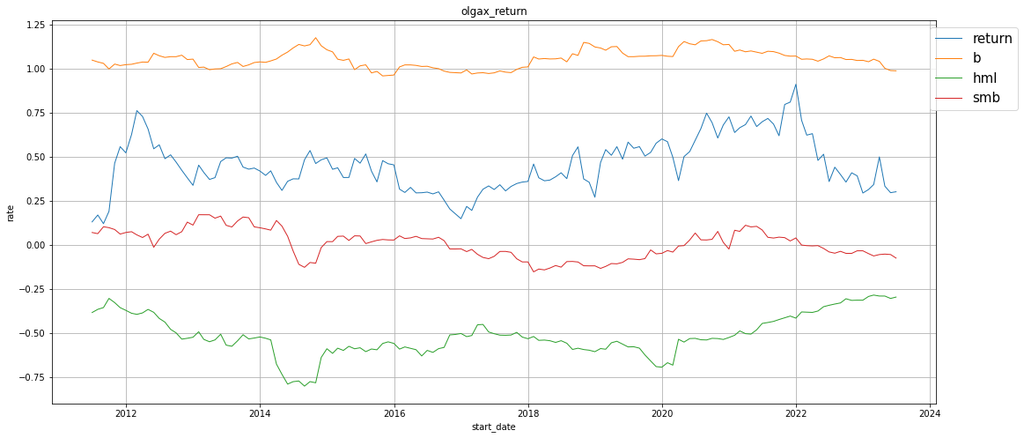

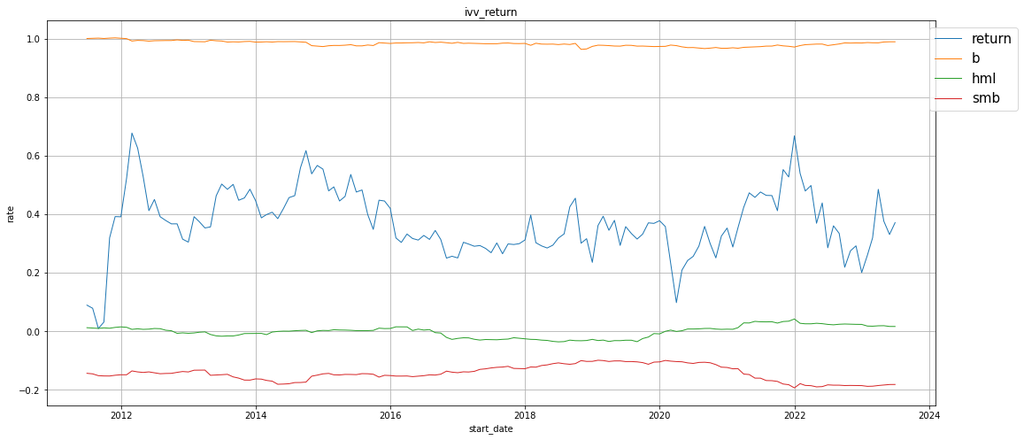

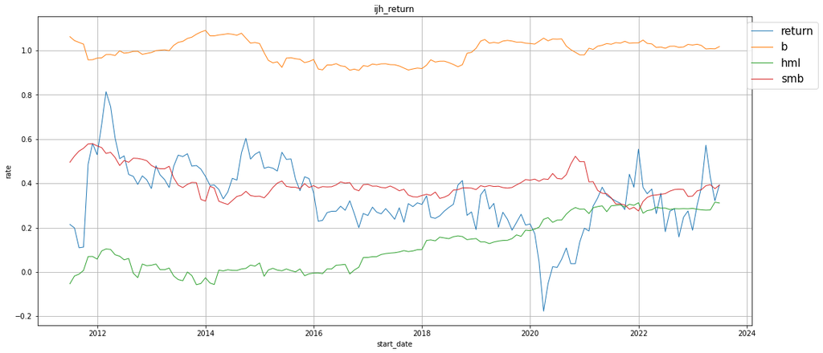

```python
total_list = []
for j in excess_re.columns:
    fund_for_analytics = pd.merge(excess_re[j],
                            data[['Mkt-RF', 'SMB', 'HML','date']],
                            left_index = True,
                            right_index = True,
                            how = 'left')
    K = 36
    bhat_list = pd.DataFrame()
    for i in range(len(fund_for_analytics)-36):
        fund_for_analytics_temp = fund_for_analytics.iloc[i:i+36]
        y = fund_for_analytics_temp [j]
        X = fund_for_analytics_temp[['Mkt-RF', 'SMB', 'HML']]/100
        X[1] = 1
        X = X[[1,'Mkt-RF', 'SMB', 'HML']]
        _,K = X.shape
        bhat = np.matmul(np.matmul(
            np.linalg.matrix_power(np.matmul(X.T.values,
                                             X.values),-1),X.T.values),y)
        yhat = np.matmul(X.values,bhat)
        uhat = y - yhat
        XtX_inv = np.linalg.inv(X.T @ X)
        uhat_squared = np.diag(uhat**2)
        varbhat = XtX_inv @ (np.matrix(X.T @ uhat_squared )@ np.matrix(X)) @ XtX_inv
        se = np.sqrt(np.diag(varbhat).astype(float))
        tstats = bhat/se
        show_output = pd.DataFrame(bhat,
                                   columns =
                                   [fund_for_analytics_temp['date'].iloc[-1]])
        show_output['se'] = se
        show_output['tstats'] = tstats
        show_output.index = ['a','b','smb','hml']
        show_output = show_output.T
        show_output['return'] = (y+1).astype(float).transform(np.log).sum()
        show_output = show_output.T
        bhat_list = bhat_list.append(
            show_output[[fund_for_analytics_temp['date'].iloc[-1]]].T
        )

    total_list.append(bhat_list)
for j in range(len(total_list)):
    data_1_for_draw = total_list[j]
    plt.figure(figsize=(18,8))
    for i in ['return','b','hml','smb']:
        plt.plot(data_1_for_draw.index,data_1_for_draw[i].values,
                    linestyle='-',  linewidth=1,label = i)

    plt.grid()
    plt.legend(fontsize=15,loc=1,bbox_to_anchor=(1.1,1.0))
    plt.xlabel('start_date')
    plt.ylabel('rate')
    plt.title(excess_re.columns[j])
    #plt.ylim(0,150)
    plt.show()
```